# Жизненный цикл Oithona

Вадим Хайтов

4 марта 2020

## Первичные данные

В анализе используется два типа данных.

1. Сборы с помощью сетки с размером ячеи 200 мкм. Годы сбора: 1961, 2018
2. Сборы с помощью сетки с размером ячеи 100 мкм. Годы сбора: 2010, 2019

## Жизненный цикл Oithona

Для начала визуализируем распределение дат, когда наблюдаются максимумы обилия каждой из стадий. Для этого отфильтруем только те данные, где обилие данной стадии больше или равно многолетней средней. Для простоты будем рассматривать только диапазон глубин 0-10 м.

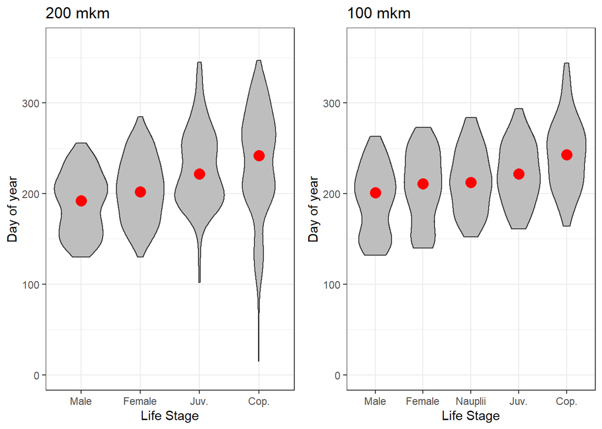

Данные с обеих сеток более или менее совпадают. Красная точка отражает медианы. Для сравнения я вывел таблицу с данными по медианам значений дат когда обилие превышает многолетнее среднее значение. Наверное, по разности значений медиан можно грубо оценить сроки развития.

Medians of Julian days when abundance of stages was higher than mean abundance calculated for all observation period (data from net 200 mkm

| Stage2 | 0_10 | 10_25 | 25_bottom |
| --- | --- | --- | --- |
| Cop. | 242 | 273 | 275 |
| Female | 202 | 212 | 223 |
| Juv. | 222 | 240 | 233 |
| Male | 192 | 202 | 211 |

Medians of Julian days when abundance of stages was higher than mean abundance calculated for all observation period (data from net 100 mkm

| Stage2 | 0_10 | 10_25 | 25_bottom |
| --- | --- | --- | --- |
| Male | 201 | 211 | 222 |
| Female | 211 | 222 | 242 |
| Nauplii | 212 | 217 | 213 |
| Juv. | 222 | 223 | 232 |
| Cop. | 243 | 260 | 274 |

Любопытно, что по обоим датасетам пики численности самцов приходятся на сроки чуть более ранние, чем пики численностей самок. Кроме того, явно читается тенденция, что на меньших глубинах пики численности всех стадий происходят раньше, чем на больших. Что это? Миграции сверху вниз или просто на разной глубине все идет независимо, но с разной скоростью?

### Анализ обилия особей разных стадий

Строим двумерную аддитивную модель, аналогичную той, что была для Microsetella.

$$log(N) = s(DOY, Year) + b_0 + \sum b_iStage_i$$

где $s$ - двумерный сплайн, описывающий поведение зависимой переменной ($log(N)$), $Stage_i$ - стадии жизненного цикла.

Вот визуализация этой модели.

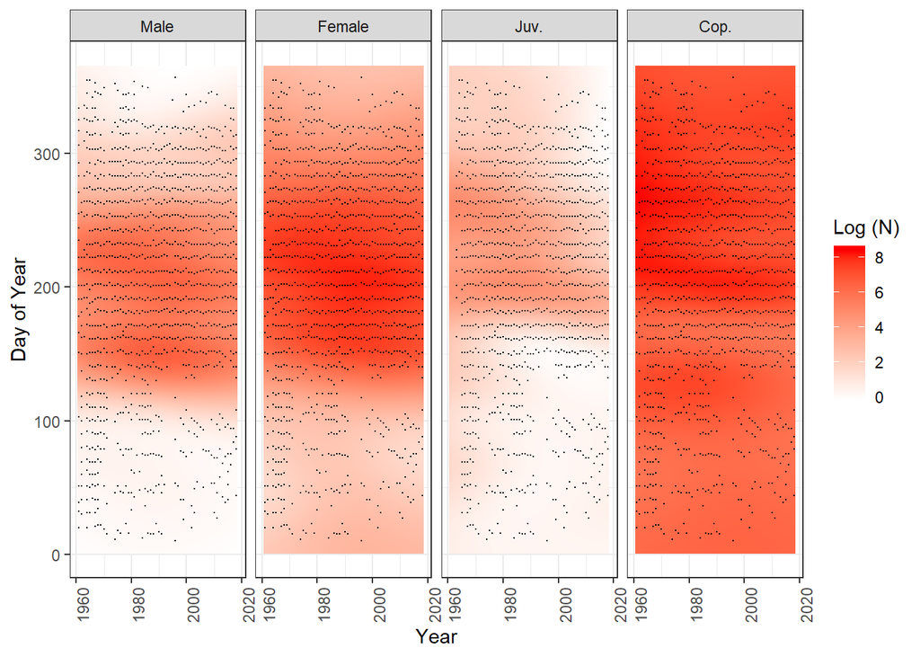

Можно заметить, следующее.

1. Пик численности самцов приходится на более узкие сроки, чем пик численности самок. Прищурив глаза можно увидеть два пика численности самцов.
2. Самки в том или ином количестве представлены весь год, Однако пик их численности приходится на те же сроки, что и у самцов (возможно, с очень незначительным сдвигом в большую сторону).
3. Пик обилия у Juv. явно смещается на все более ранние сроки.
4. Копеподиты обильны круглогодично, но с предсказуемым небольшим провалом перед пиком самцов и самок.

Если построить аналогичную картинку для сетки 100 мкм, то в принципе результаты те же.

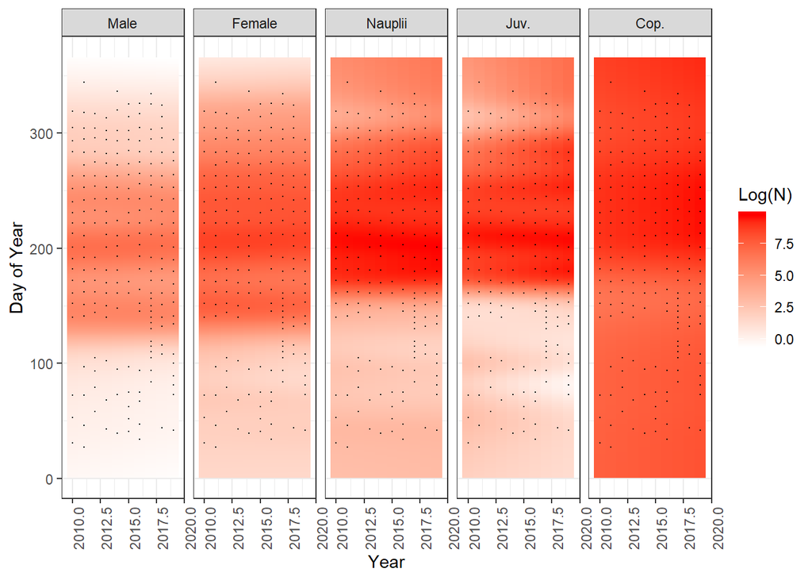

Несколько пиков самцов и самок становятся видны более отчетливо.

Опять же виден небольшой провал в численности копеподитов перед пиком взрослых.

Тенденция смещения пика ювенилов на более ранние сроки на этом датасете не видна, но это потому, что в этом датасете приведены лишь наблюдения за последние 10 лет.

В принципе, аналогичная картинка будет, если построить модель без учета года. Вот, если рассматривать только глубину 0-10 м, получается такая картинка.

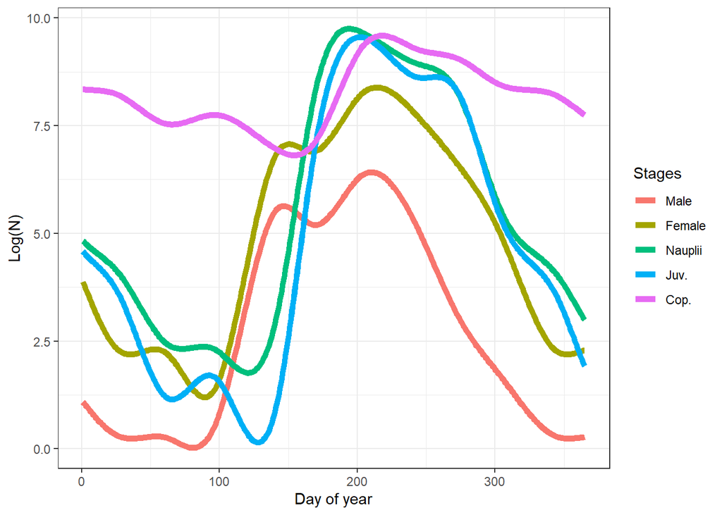

Здесь становится хорошо заметна двупиковость численности самцов и самок. Интересно, что в статье Cornwell et al. 2020 тоже отмечали два пика, правда на общей численности. Кстати, эта двупиковость прослеживается и на на науплиусах и на ювенилах.

В случае оитоны, кстати, в отличие от микросетеллы, обилие копеподитов превышает обилие взрослых. Это еще один довод в пользу того, что мы, скорее всего наблюдаем у микросетеллы какие-то процессы, связанные с миграцией.

## Сопоставление сезонных процессов у Oithona и Microsetella на всем дипазоне глубины

### По материалам сетки 100 мкм

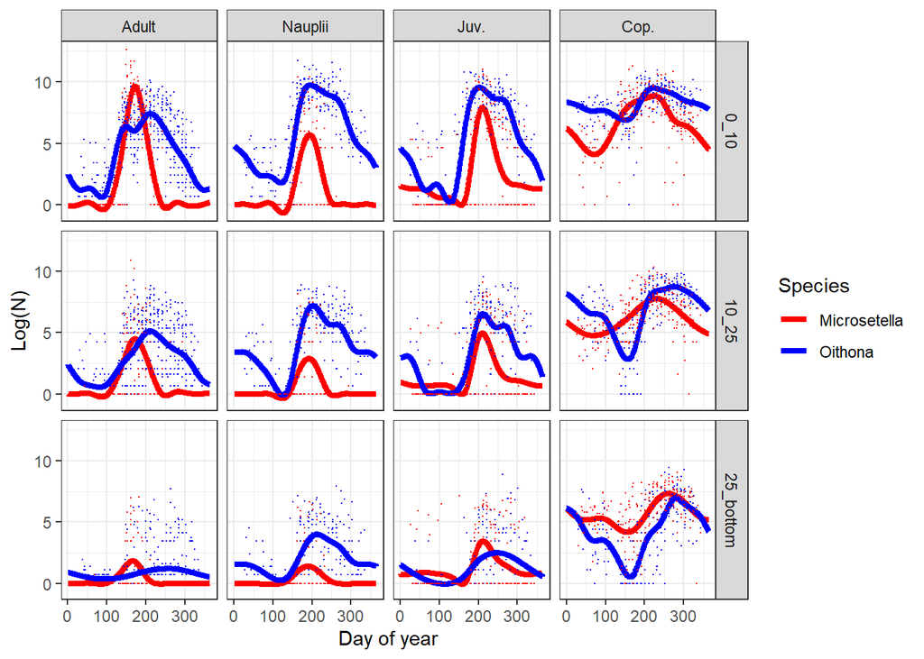

### По материалам сетки 200 мкм

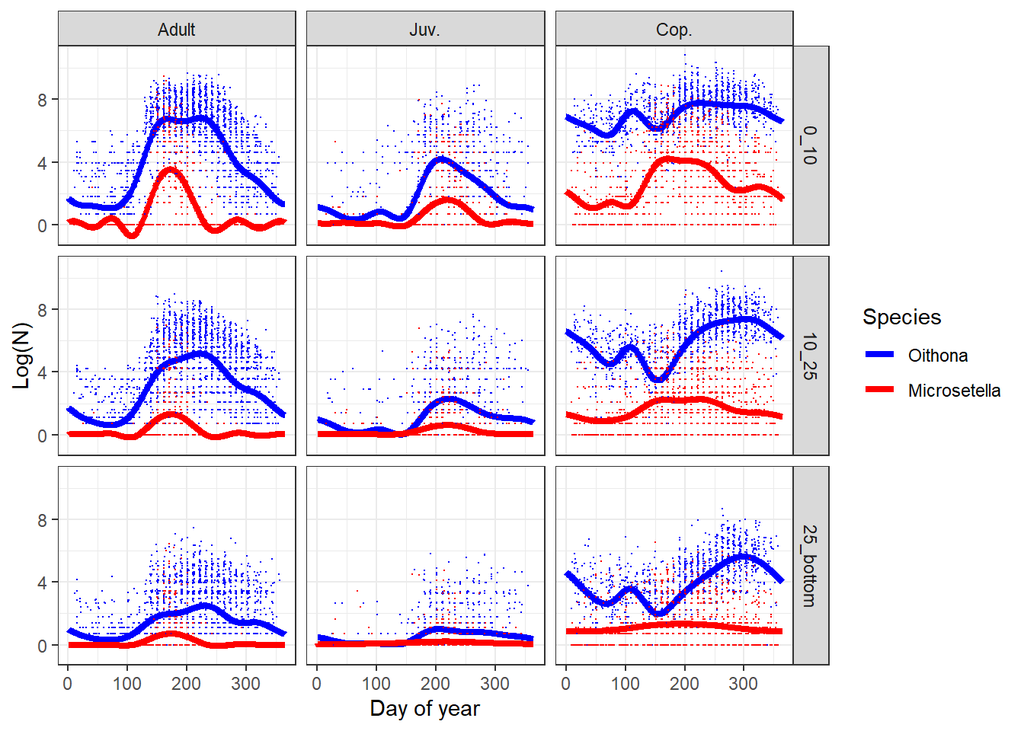

Здесь подобраны модели (GAM) для каждой стадии, каждого вида для каждого диапазона глубины. Точки - первичные данные.

Неплохо просматривается тенденция появления взрослых особей у оитоны чуть позднее, чем у микросетеллы. Соответственно и все остальные стадии у оитоны дают пики чуть позднее, чем пики соответствующих стадий у микросетеллы.

Насколько все это не бред не знаю, но у меня устойчивое впечатление, что оитона, хоть и более обильна, действительно, свой цикл подстраивает под обилие микросетеллы. Вряд ли что-то кардинально меняется в среде за те несколько дней на которые у нее смещаются пики в отношении пиков микросетеллы.